# xwMOOC 자동차

차량 내구성 조사(VDS)

xwMOOC

2017-12-24

## 1. 자동차 품질 지표 - VDS

미국 [JD 파워](http://www.jdpower.com/)가 매년 실시하는 미국시장 초기품질지수(Initial Quality Survey)는 자동차 100대당 결함갯수를 나타나는 것으로 숫자가 낮을수록 자동차 초기 품질이 높다는 의미를 갖는다.

JD파워에서 해당 자동차를 실제로 구입한 사람들을 대상으로 실시하는 조사는 두가지가 유명하다. 초기품질조사는 구매한지 90일이 지난 소비자를 대상으로 한 조사이며, 자동차 내구성 조사(VDS, Vehicle Dependability Study)는 차량을 구매한 지 3년이 지난 소비자를 대상으로 한 조사다.

초기품질조사에 대한 이전 데이터 분석 결과는 **초기품질지수(IQS)**을 참조한다.

## 2. JD 파워 VDS 데이터

JD 파워 VDS 데이터가 [JD 파워](http://www.jdpower.com/) 웹사이트에서 [Technology Woes Continue to Drive Up Problems: J.D. Power Vehicle Dependability Study](http://www.jdpower.com/press-releases/2016-us-vehicle-dependability-study-vds)와 같은 형태로 제공된다. 이를 종합하면 JD 파워에서 원천데이터를 제공하는데 기본은 PDF 파일인데 특정년도는 PDF내부 이미지 형태로 제공하기 때문에 OCR 기법을 활용해서 데이터를 추출해야한다.

- PDF 파일에서 텍스트를 추출하여 표형태 데이터로 변환
- PDF 파일에서 이미지를 추출하여 OCR을 통해 표형태 데이터로 변환

### 2.1. 환경설정

OCR을 위한 `tesseract`, PDF 데이터 추출을 위한 `pdftools`, 텍스트 데이터 전처리를 위한 `stringr` 및 필요한 팩키지도 함께 준비한다.

```r
# 0. 환경설정 ---------------
library(tidyverse)
library(rvest)
library(tesseract)
library(pdftools)
library(stringr)
library(forcats)
library(ggpubr)
library(extrafont)
loadfonts()
library(gridExtra)
library(lubridate)
```

### 2.2. 데이터 가져오기

pdf 파일을 가져오는 것은 2011 - 2017년까지 동일하나 제공되는 IQS 정보가 PDF 텍스트냐, 이미지냐에 따라 처리방향이 다르다. 텍스트인 경우 PDF 파일에서 텍스트를 추출하여 VDS 제조사와 결함갯수(문제갯수)만 정규표현식을 활용하여 추출하여 데이터프레임으로 저장한다.

이미지인 경우 PDF 파일에서 이미지를 추출하여 `tiff` 형태로 저장하고 이를 바탕으로 텍스트를 추출하여 마찬가지로 IQS 제조사와 결함갯수(문제갯수)만 정규표현식을 활용하여 추출하여 데이터프레임으로 저장한다.

```r
# 1. 데이터 가져오기 ---------------
## 1.1. 2011 년 --------------------
vds_2011_pdf <- pdf_text("data/vds_2011.pdf")

vds_2011_lst <- unlist(strsplit(vds_2011_pdf[1], split = "\\n"))
vds_2011_lst <- vds_2011_lst[7:41]
vds_2011_lst <- str_replace_all(vds_2011_lst, "^\\s*", "")
vds_2011_lst <- str_split(vds_2011_lst, "\\s{2,100}")

vds_2011_df <- do.call(rbind, vds_2011_lst) %>%
  as_tibble() %>%
  rename(제조사 = V1, 문제갯수=V2) %>%
  mutate(문제갯수 = as.integer(str_replace_all(문제갯수, "\r", "")))

saveRDS(vds_2011_df, "data_processed/vds_2011_df.rds")

## 1.2. 2012 년 --------------------
vds_2012_pdf <- pdf_text("data/vds_2012.pdf")

vds_2012_lst <- unlist(strsplit(vds_2012_pdf[1], split = "\\n"))
vds_2012_lst <- vds_2012_lst[7:39]
vds_2012_lst <- str_replace_all(vds_2012_lst, "^\\s*", "")
vds_2012_lst <- str_split(vds_2012_lst, "\\s{2,100}")

vds_2012_df <- do.call(rbind, vds_2012_lst) %>%
  as_tibble() %>%
  rename(제조사 = V1, 문제갯수=V2) %>%
  mutate(문제갯수 = as.integer(str_replace_all(문제갯수, "\r", "")))

saveRDS(vds_2012_df, "data_processed/vds_2012_df.rds")

## 1.3. 2013 년 --------------------
vds_2013_file <- pdftools::pdf_convert("data/vds_2013018-vds.pdf", format = 'tiff', pages = 4, dpi = 400)
```

```
Converting page 4 to vds_2013018-vds_4.tiff... done!
```

```r
vds_2013_lst <- ocr(vds_2013_file)
unlink(vds_2013_file)

vds_2013_lst <- unlist(str_split(vds_2013_lst, "\n"))
vds_2013_lst <- vds_2013_lst[6:38]

vds_2013_maker <- purrr::map(str_extract_all(vds_2013_lst, "[:alpha:]+"), str_c, collapse="") %>% unlist
vds_2013_num <- str_extract_all(vds_2013_lst, "[0-9]+$") %>% unlist

vds_2013_df <- tibble(제조사=vds_2013_maker, 문제갯수=vds_2013_num) %>%
  mutate(문제갯수 = as.integer(문제갯수))

saveRDS(vds_2013_df, "data_processed/vds_2013_df.rds")

## 1.4. 2014 년 --------------------
vds_2014_file <- pdftools::pdf_convert("data/vds_2014009 VDS 2014.pdf", format = 'tiff', pages = 3, dpi = 400)
```

```
Converting page 3 to vds_2014009 VDS 2014_3.tiff... done!
```

```r
vds_2014_lst <- ocr(vds_2014_file)
unlink(vds_2014_file)

vds_2014_lst <- unlist(str_split(vds_2014_lst, "\n"))
vds_2014_lst <- vds_2014_lst[5:36]

vds_2014_maker <- purrr::map(str_extract_all(vds_2014_lst, "[:alpha:]+"), str_c, collapse="") %>% unlist
vds_2014_num <- str_extract_all(vds_2014_lst, "[0-9]+$") %>% unlist

vds_2014_df <- tibble(제조사=vds_2014_maker, 문제갯수=vds_2014_num) %>%
  mutate(문제갯수 = as.integer(문제갯수))

saveRDS(vds_2014_df, "data_processed/vds_2014_df.rds")

## 1.5. 2015 년 --------------------
vds_2015_file <- pdftools::pdf_convert("data/vds_2015020 VDS_Final.pdf", format = 'tiff', pages = 3, dpi = 400)
```

```
Converting page 3 to vds_2015020 VDS_Final_3.tiff... done!
```

```r
vds_2015_lst <- ocr(vds_2015_file)
unlink(vds_2015_file)

vds_2015_lst <- unlist(str_split(vds_2015_lst, "\n"))
vds_2015_lst <- vds_2015_lst[5:36]

vds_2015_maker <- purrr::map(str_extract_all(vds_2015_lst, "[:alpha:]+"), str_c, collapse="") %>% unlist
vds_2015_num <- str_extract_all(vds_2015_lst, "[0-9]+$") %>% unlist

vds_2015_df <- tibble(제조사=vds_2015_maker, 문제갯수=vds_2015_num) %>%
  mutate(문제갯수 = as.integer(문제갯수))

saveRDS(vds_2015_df, "data_processed/vds_2015_df.rds")

## 1.6. 2016 년 --------------------
vds_2016_pdf <- pdf_text("data/vds_2016027_us_vds_v3.pdf")

vds_2016_lst <- unlist(strsplit(vds_2016_pdf[3], split = "\\n"))
vds_2016_lst <- vds_2016_lst[5:37]
vds_2016_lst <- str_replace_all(vds_2016_lst, "^\\s*", "")
vds_2016_lst <- str_split(vds_2016_lst, "\\s{2,100}")

vds_2016_df <- do.call(rbind, vds_2016_lst) %>%
  as_tibble() %>%
  rename(제조사 = V1, 문제갯수=V2) %>%
  mutate(문제갯수 = as.integer(str_replace_all(문제갯수, "\r", "")))

saveRDS(vds_2016_df, "data_processed/vds_2016_df.rds")

## 1.7. 2017 년 --------------------
vds_2017_pdf <- pdf_text("data/vds_2017017_vds.pdf")

vds_2017_lst <- unlist(strsplit(vds_2017_pdf[3], split = "\\n"))
vds_2017_lst <- vds_2017_lst[5:36]
vds_2017_lst <- str_replace_all(vds_2017_lst, "^\\s*", "")
vds_2017_lst <- str_split(vds_2017_lst, "\\s{2,100}")

vds_2017_df <- do.call(rbind, vds_2017_lst) %>%
  as_tibble() %>%
  rename(제조사 = V1, 문제갯수=V2) %>%
  mutate(문제갯수 = as.integer(str_replace_all(문제갯수, "\r", "")))

saveRDS(vds_2017_df, "data_processed/vds_2017_df.rds")
```

PDF 파일 및 웹사이트에서 연도별로 추출하여 정제한 데이터를 `.rds` 파일형태로 저장했다면, 다음 단계로 이를 불러와서 시각화 및 관련된 모형 작업을 수행한다.

### 3.1. 추출한 데이터 가져오기 및 정제 작업

PDF 파일 혹은 웹사이트에서 긁어오는 과정에서 제조사명에 오류가 있는 경우 수정하고, 시각화를 위해서 제조사 정보를 요인형 자료구조에 대해 수정 작업을 수행한다.

```r
# 1. 데이터 가져오기 ---------------
## 1.1. 연도별 IQS 데이터 가져오기
vds_2011_df <- readRDS("data_processed/vds_2011_df.rds") %>% mutate(연도 ="2011")
vds_2012_df <- readRDS("data_processed/vds_2012_df.rds") %>% mutate(연도 ="2012")
vds_2013_df <- readRDS("data_processed/vds_2013_df.rds") %>% mutate(연도 ="2013")
vds_2014_df <- readRDS("data_processed/vds_2014_df.rds") %>% mutate(연도 ="2014")
vds_2015_df <- readRDS("data_processed/vds_2015_df.rds") %>% mutate(연도 ="2015")
vds_2016_df <- readRDS("data_processed/vds_2016_df.rds") %>% mutate(연도 ="2016")
vds_2017_df <- readRDS("data_processed/vds_2017_df.rds") %>% mutate(연도 ="2017")

## 1.2. IQS 데이터 병합

vds_df <-   vds_2011_df %>%
  bind_rows(vds_2012_df) %>%
  bind_rows(vds_2013_df) %>%
  bind_rows(vds_2014_df) %>%
  bind_rows(vds_2015_df) %>%
  bind_rows(vds_2016_df) %>%
  bind_rows(vds_2017_df)

vds_df %>% spread(연도, 문제갯수) %>%
  DT::datatable()
```

|  | 제조사 | 2011 | 2012 | 2013 | 2014 | 2015 | 2016 | 2017 |
| --- | --- | --- | --- | --- | --- | --- | --- | --- |
| 1 | Acura | 123 | 129 | 120 | 109 | 124 | 129 | 167 |
| 2 | Audi | 161 | 148 | 147 | 151 | 138 | 134 | 153 |
| 3 | BMW | 164 | 154 | 133 | 130 | 146 | 142 | 139 |
| 4 | Buick | 125 | 125 | 18 | 112 | 110 | 106 | 126 |
| 5 | Cadillac | 130 | 104 | 128 | 107 | 114 | 145 | 152 |
| 6 | Chevrolet | 156 | 135 | 125 | 132 | 123 | 125 | 142 |
| 7 | Chrysler | 202 | 192 | 153 | 155 | 173 | 165 | 159 |
| 8 | Dodge | 206 | 183 | 190 | 181 | 192 | 208 | 187 |
| 9 | Fiat |  |  |  |  | 273 | 171 | 298 |
| 10 | Ford | 140 | 124 | 127 | 140 | 188 | 204 | 183 |

[output cut: 31 more lines]

```r
# 2. 데이터 전처리 ------------------------
## 2.1. 제조사 코드 정리
vds_df <- vds_df %>% mutate(제조사 = case_when(
  제조사 == "IndustryAverage" ~ "Industry Average",
  제조사 == "LandRover" ~ "Land Rover",
  제조사 == "MercedesBenz" ~ "Mercedes-Benz",
  str_detect(제조사, "niti$") ~ "infiniti",
  str_detect(제조사, "ni6$") ~ "infiniti",
  제조사 == "Mini" ~ "MINI",
  TRUE ~ 제조사
))


## 2.2. 시각화 및 모형 데이터프레임 변환------
vds_df <- vds_df %>%
  mutate(IQS산업평균 = ifelse(stringr::str_detect(제조사, "Industry Average"), "산업평균", "제조사")) %>%
  mutate(현대기아 = case_when(
    stringr::str_detect(제조사, "Kia") ~ "기아",
    stringr::str_detect(제조사, "Hyundai") ~ "현대",
    stringr::str_detect(제조사, "Industry Average") ~ "산업평균",
    TRUE ~ "해외업체"
  )) %>%
  mutate(제조사 = factor(제조사),
          현대기아 = factor(현대기아, levels=c("기아", "현대", "산업평균", "해외업체")))
```

### 3.2. 최근 특정년도 제조사별 VDS 점수

가장 최근 2017년 VDS 차량 내구성 조사 결과를 시각화한다.

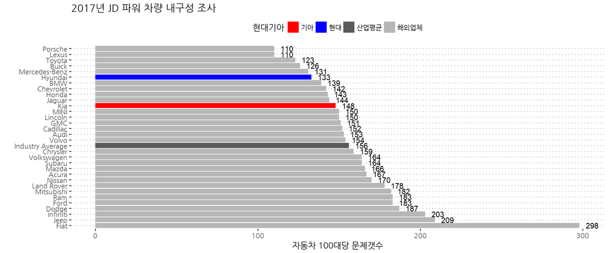

```r
# 3. 시각화 ---------------
## 3.0. 색상 팔레트 설정
vds_hkmc_cols <- c(기아 = "#ff0000",
                   현대 = "#0000ff",
                   산업평균 = "#5b5b5b",
                   해외업체 = "#b7b7b7")

## 3.1. 최신 차량 내구성 조사
vds_df %>% filter(연도 == "2017") %>%
  ggplot(aes(x = reorder(제조사, -문제갯수), y = 문제갯수, fill = 현대기아 ) ) +
    geom_bar(stat = "identity") +
    scale_fill_manual(values=vds_hkmc_cols) +
    geom_text(aes(label=문제갯수), vjust=0.5, hjust=-0.5) +
    coord_flip() +
    labs(x="", y="자동차 100대당 문제갯수", title="2017년 JD 파워 차량 내구성 조사") +
    theme_pubclean(base_family="NanumGothic")
```

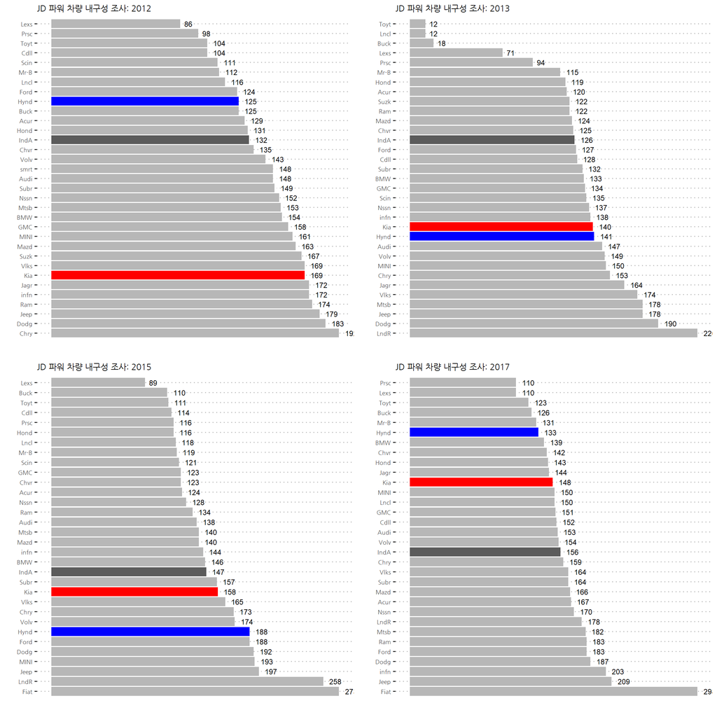

```r
## 3.2. IQS 시각화 함수
barplot_vds <- function(year) {
  vds_df %>% filter(연도 == year) %>%
    ggplot(aes(x = reorder(제조사, -문제갯수), y = 문제갯수, fill = 현대기아) ) +
    geom_bar(stat = "identity") +
    scale_fill_manual(values=vds_hkmc_cols) +
    geom_text(aes(label=문제갯수), vjust=0.5, hjust=-0.5, size=3) +
    scale_x_discrete(labels = abbreviate) +
    coord_flip() +
    labs(x="", y="", title=paste0("JD 파워 차량 내구성 조사: ", year)) +
    theme_pubclean(base_family="NanumGothic") +
    theme(legend.position = "none",
          axis.text=element_text(size=7),
          plot.title = element_text(size=10),
          axis.text.x=element_blank(),
          axis.ticks.x=element_blank())
}

# barplot_vds("2011")

## 3.3. 최근 4년 시간순 비교

for(year in 2012:2017) {
  plot_name <- paste0("vds_p", year)
  assign(plot_name, barplot_vds(year))
}

plot_list <- mget(paste0("vds_p", c(2012, 2013, 2015, 2017)))

do.call(grid.arrange, plot_list)
```

### 3.4. 2011-2017년 연도별 VDS 점수 변화 추세

2011-2017년 연도별 VDS 점수 변화에 대한 추세도 살펴볼 수 있다.

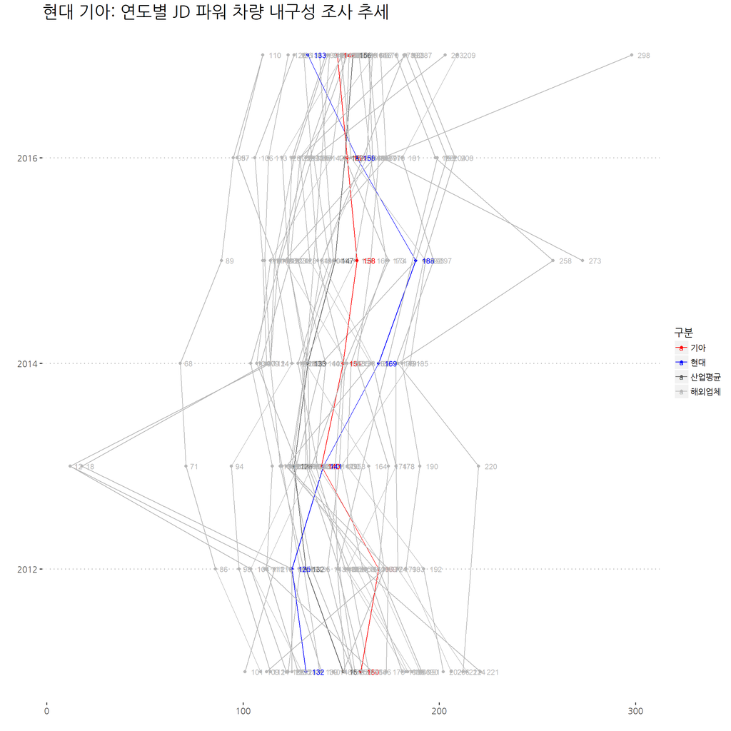

```r
# 4. 시계열 분석 ---------------------
vds_df %>% mutate(연도 = make_date(year=연도, month="01", day="01")) %>%
  ggplot(aes(x=연도, y=문제갯수, group=제조사, color=현대기아)) +
    geom_point() +
    geom_line() +
    scale_color_manual(values=vds_hkmc_cols) +
    geom_text(aes(label=문제갯수), vjust=0.5, hjust=-0.5, size=3) +
    scale_x_date(date_labels = "%Y") +
    coord_flip() +
    labs(x="", y="", color="구분", title="현대 기아: 연도별 JD 파워 차량 내구성 조사 추세") +
    theme_pubclean(base_family="NanumGothic") +
    theme(legend.position = "right",
        axis.text=element_text(size=10),
        plot.title = element_text(size=20))
```